# MFA Plotting with mfaMKTLT

Minchul Shin, Ko Donghyeon, Taehee Jung, Lev Golod, Temi N Lal

2016-12-01

## Initializing an `"mfa"` Object

First, let’s get an `"mfa"` object up and running. We will analyze the wine  
data, and use all of the default arguments.

```r
sets.num <- list(c(1:6), c(7:12), c(13:18), c(19:23), c(24:29), c(30:34),
  c(35:38), c(39:44), c(45:49), c(50:53))
mfa1 <- mfa(data = winedata, sets = sets.num)
mfa1
```

```
#> object "mfa"
#> Data analyzed: winedata,
#>               with 12 objects (rows)
#>               and 53 active variables (columns)
#> Number of sub-tables analyzed:  10
#> Number of components generated: 12
#> Column centering:               mean-centering
#> Column scaling:                 divide by standard deviation
```

## Compromise/Common Factor Scores

As the name suggests, the Compromise Factor Scores represent a compromise among  
the sub-tables regarding the coordinates of each object (row) along the  
components. The user can choose which components she or he wants to see. Let’s  
start by looking at components 1 and 2. These happen to be the default components.

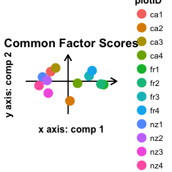

```r
plot(mfa1, type = "compromise", mytitle = "Common Factor Scores")
```

We can choose different components if we like. Let’s plot component 3 on the  
x-axis with `xdim` and component 7 on the y-axis with `ydim`. We can control  
the point size with `size`. These new plot points are big-league!

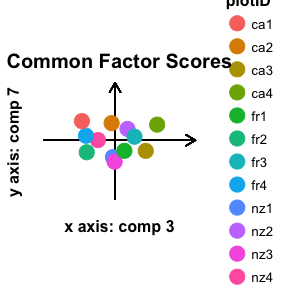

```r
plot(mfa1, type = "compromise", xdim = 3, ydim = 7, size = 5,
  mytitle = "Common Factor Scores")
```

Default legend of this plot is rownames, which is mached to observation name.  
But we can set up legend as we want. Since rownames have the pattern, which  
is two characters of nation + number, let’s set up legend as first two  
characters of rownames and label with last number. Now, the graph looks more  
recognizable than the previous one.

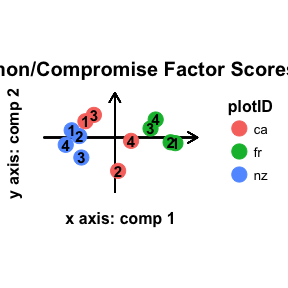

```r
plot(mfa1, type = "compromise", legend=substr(rownames(mfa1$Fcommon),1,2),
label=substr(rownames(mfa1$Fcommon),3,3))
```

## Partial Factor Scores

The Partial Factor Scores plot lets us see where the objects fall along the  
component axes for each individual sub-table. The user can choose which  
sub-table(s) she/he wants to see with `subtabs`. The default value, `NULL`,  
means that all sub-tables will be displayed. As before, we can also choose  
the point size, and which components we are interested in.

As we may observe, displaying too many sub-tables at once may make the plot  
very hard to read. It may be preferable to look at a few at a time. Note that  
if we don’t supply a title, the function will choose a title automatically,  
based on the `type` of the plot. When dealing with multiple sub-plots, we may  
also use `facetrows` to control how many rows the sub-plots are placed into.  
The default value is 2.

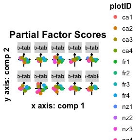

```r
plot(mfa1, type = "partial.factor", size = 2)
```

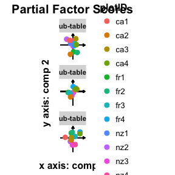

```r
plot(mfa1, type = "partial.factor", size = 2.5, subtabs = c(1,2,4),
     xdim = 4, ydim = 2, facetrows = 3)
```

Also, legend and label can be used in the same way as we did in the compromise  
factor score.

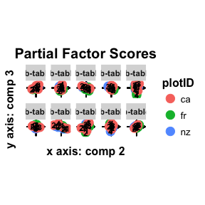

```r
plot(mfa1, type = "partial.factor", size = 4, subtabs = NULL, xdim = 2, ydim = 3,
     legend=substr(rownames(mfa1$Fpartial[[1]]),1,2),
     label=substr(rownames(mfa1$Fcommon),3,3))
```

## Loadings

This plot displays the Loadings, which are the right singular vectors from the  
Generalized Singular Value Decomposition that is computed as part of MFA.

As we may learn by reading the documentation for `winedata`, each of the  
critics used the first four variables, cat pee, passion fruit, green pepper,  
and mineral, to assess the wines. Each critic was also free to choose as many  
as two additional variables. Let’s use this information to make a more  
informative legend, using the optional `legend` paramter. For ease of reading,  
we will only look at sub-tables 9 and 10.

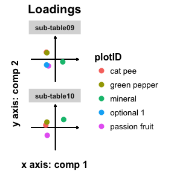

```r
plot(mfa1, type = "loadings", size = 2.5, subtabs = c(9,10),
     legend = c("cat pee", "passion fruit", "green pepper", "mineral",
                "optional 1", "optional 2"))
```

## Eigenvalues

In this plot, we use the eigenvalues, which is a default value in the mfa object.  
Thus, no arguments except data and type are used in this plot. Based on the  
eigenvalues of the components, bar chart is plotted.

```
#> Eigenvalue plot only uses first 2 arguments.
```

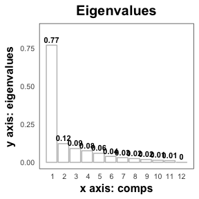

```r
plot(mfa1, type = "eigenvalues")
```

## Compromise + Partial Factor Scores

using type ‘compromise.partial’, first two plots can be combined in an one plot.  
Arguments xdim/ydim can be chosen by user.

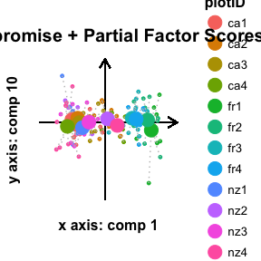

```r
plot(mfa1, type = "compromise.partial", xdim = 1, ydim = 10)
```

Note that legend and label can be applied on this plot, too.

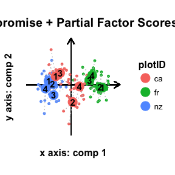

```r
plot(mfa1, type = "compromise.partial", xdim = 1, ydim = 2, size = 5,
     legend=substr(rownames(mfa1$Fcommon),1,2), label=substr(rownames(mfa1$Fcommon),3,3))
```

## Bootstrap ratio plots

Final plot is drawn by the result of bootstrap function. This function first  
gets the bootstrap samples of the partial factor scores with sample size as a  
value of argument bootstrap_size. Its difualt value is 1000. Then it calculates  
the t-value, which is bootstrap mean divided by standard deviation. Function  
results keep this t-value, and also bootstrap mean and standard deviation.

The plot value is based on the component’s t-value of the bootstrap result.  
It is a rotated bar chart where the x-axis is the t-value and y-axis is the  
observation name(=rownames.) Users can choose as many components as they  
want with the argument bootstrap_comps. The defaule value is c(1,2). Since  
final plots are represented as a multi-plots on one page, we can control how  
many rows the sub-plots are placed into with the argument `facetrows`. The  
default value of this argument is 2.

```
#> Bootstrap sample only creates with Partial Factor scores.
```

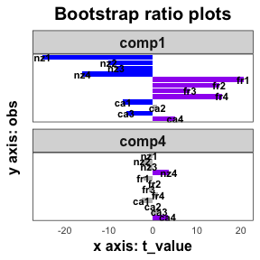

```r
plot(mfa1, type= "bootstrap", bootstrap_size = 2000, bootstrap_comps=c(1,4), facetrows=2)
```